# Project proposal

## Instructions

1. Please answer the following questions as part of your project proposal.
2. Write your answers in the *Markdown* cells of the Jupyter notebook. You don’t need to write any code, but if you want to, you may use the *Code* cells.
3. Use [Quarto](https://quarto.org/docs/output-formats/html-basics.html) to print the *.ipynb* file as HTML. You will need to open the command prompt, navigate to the directory containing the file, and use the command: `quarto render filename.ipynb --to html`. Submit the HTML file.
4. The project proposal is worth 8 points, and is due on **18th April 2023 at 11:59 pm**.
5. You must make one submission as a group, and not individually.
6. Maintaining a GitHub repository is optional, though encouraged for the project.
7. Share the link of your project’s GitHub repository [here](https://docs.google.com/spreadsheets/d/1khao3unpj_vsx4kOSg_Zzo77YK1UWL2w73Oa0aAirOo/edit#gid=0) (optional).

# 1) Team name

Mention your team name.

*(0 points)*

AACK

# 2) Member names

Mention the names of your team members.

*(0 points)*

Karrine Denisova, Ally Bardas, Catherine Erickson, Annabel Skubisz

# 3) Link to the GitHub repository (optional)

Share the link of the team’s project repository on GitHub.

Also, put the link of your project’s GitHub repository [here](https://docs.google.com/spreadsheets/d/1khao3unpj_vsx4kOSg_Zzo77YK1UWL2w73Oa0aAirOo/edit#gid=0).

We believe there is no harm in having other teams view your GitHub repository. However, if you don’t want anyone to see your team’s work, you may make the repository *Private* and add your instructor and graduate TA as *Colloborators* in it.

*(0 points)*

https://github.com/catherineerickson/STAT-303-3-Project

# 4) Topic

Mention the topic of your course project.

*(0 points)*

Water Quality and Potability Prediction

# 5) Problem statement

*(4 points)*

Explain the problem statement. The problem statement must include:

## 5a) The problem

Potable water is fundamental to the health of communities and a necessary factor of policy surrounding public health. Additionally, water quality is important as a developmental and economic factor of a location. Therefore, understanding and predicting water quality is crucial. Our project aims to predict whether or not water is potable based on given metrics of water from 3,276 different bodies of water. These metrics include factors such as pH value, hardness, TDS, and sulfates.

## 5b) Type of response

Is it about predicting a continuous response or a binary response or a combination of both?

This is about predicting a binary response, whether water is potable or not.

## 5c) Performance metric

How will you assess model accuracy?

- If it is a classification problem, then which measure(s) will you optimize for your model – precision, recall, false negative rate (FNR), accuracy, ROC-AUC etc., and why?
- If it is a regression problem, then which measure(s) will you optimize for your model – RMSE (Root mean squared error), MAE (mean absolute error), maximum absolute error etc., and why?

Because it is worse to say that water quality is good when it is indeed bad, we are minimizing False Positives, and maximizing precision. If citizens and health officials believe that the water is of good quality, they may take less filtering and preventative measures, leaving citizens vulnerable to drinking unhealthy water.

## 5d) Naive model accuracy

What is the accuracy of the naive model (Standard deviation of response in case of continuous response / proportion of the majority class in case of classification model)

```python
import statsmodels.formula.api as smf
import pandas as pd
import numpy as np
from sklearn.metrics import roc_curve, auc
import seaborn as sns
import matplotlib.pyplot as plt
```

```python
train = pd.read_csv("water_potability.csv")
train.head()
```

|  | ph | Hardness | Solids | Chloramines | Sulfate | Conductivity | Organic_carbon | Trihalomethanes | Turbidity | Potability |
| --- | --- | --- | --- | --- | --- | --- | --- | --- | --- | --- |
| 0 | NaN | 204.890455 | 20791.318981 | 7.300212 | 368.516441 | 564.308654 | 10.379783 | 86.990970 | 2.963135 | 0 |
| 1 | 3.716080 | 129.422921 | 18630.057858 | 6.635246 | NaN | 592.885359 | 15.180013 | 56.329076 | 4.500656 | 0 |
| 2 | 8.099124 | 224.236259 | 19909.541732 | 9.275884 | NaN | 418.606213 | 16.868637 | 66.420093 | 3.055934 | 0 |
| 3 | 8.316766 | 214.373394 | 22018.417441 | 8.059332 | 356.886136 | 363.266516 | 18.436524 | 100.341674 | 4.628771 | 0 |
| 4 | 9.092223 | 181.101509 | 17978.986339 | 6.546600 | 310.135738 | 398.410813 | 11.558279 | 31.997993 | 4.075075 | 0 |

```python
column_counts = train['Potability'].value_counts()
column_counts
```

```
0    1998
1    1278
Name: Potability, dtype: int64
```

```python
train.isnull().sum()
```

```
ph                 491
Hardness             0
Solids               0
Chloramines          0
Sulfate            781
Conductivity         0
Organic_carbon       0
Trihalomethanes    162
Turbidity            0
Potability           0
dtype: int64
```

```python
#Replace null values based on the sample mean
train['ph']=train['ph'].fillna(train.groupby(['Potability'])['ph'].transform('mean'))
train['Sulfate']=train['Sulfate'].fillna(train.groupby(['Potability'])['Sulfate'].transform('mean'))
train['Trihalomethanes']=train['Trihalomethanes'].fillna(train.groupby(['Potability'])['Trihalomethanes'].transform('mean'))
```

```python
train.isnull().sum()
```

```
ph                 0
Hardness           0
Solids             0
Chloramines        0
Sulfate            0
Conductivity       0
Organic_carbon     0
Trihalomethanes    0
Turbidity          0
Potability         0
dtype: int64
```

```python
column_list = train.columns.to_list()[:-1] #not including response
column_list
```

```
['ph',
 'Hardness',
 'Solids',
 'Chloramines',
 'Sulfate',
 'Conductivity',
 'Organic_carbon',
 'Trihalomethanes',
 'Turbidity']
```

```python
#Logistic regression model with all predictors - baseline model
formula = 'Potability~'+'+'.join(column_list)

logit_model = smf.logit(formula=formula, data=train).fit()
logit_model.summary()
```

```
Optimization terminated successfully.
         Current function value: 0.667054
         Iterations 4
```

Logit Regression Results

| Dep. Variable: | Potability | No. Observations: | 3276 |
| --- | --- | --- | --- |
| Model: | Logit | Df Residuals: | 3266 |
| Method: | MLE | Df Model: | 9 |
| Date: | Mon, 17 Apr 2023 | Pseudo R-squ.: | 0.002606 |
| Time: | 14:13:57 | Log-Likelihood: | -2185.3 |
| converged: | True | LL-Null: | -2191.0 |
| Covariance Type: | nonrobust | LLR p-value: | 0.2481 |

|  | coef | std err | z | P>\|z\| | [0.025 | 0.975] |
| --- | --- | --- | --- | --- | --- | --- |
| Intercept | 0.0354 | 0.614 | 0.058 | 0.954 | -1.169 | 1.240 |
| ph | 0.0032 | 0.025 | 0.129 | 0.898 | -0.045 | 0.051 |
| Hardness | -0.0009 | 0.001 | -0.790 | 0.429 | -0.003 | 0.001 |
| Solids | 7.485e-06 | 4.16e-06 | 1.800 | 0.072 | -6.65e-07 | 1.56e-05 |
| Chloramines | 0.0332 | 0.023 | 1.458 | 0.145 | -0.011 | 0.078 |
| Sulfate | -0.0013 | 0.001 | -1.306 | 0.192 | -0.003 | 0.001 |
| Conductivity | -0.0002 | 0.000 | -0.469 | 0.639 | -0.001 | 0.001 |
| Organic_carbon | -0.0181 | 0.011 | -1.666 | 0.096 | -0.039 | 0.003 |
| Trihalomethanes | 0.0008 | 0.002 | 0.344 | 0.731 | -0.004 | 0.005 |
| Turbidity | -9.813e-05 | 0.046 | -0.002 | 0.998 | -0.090 | 0.090 |

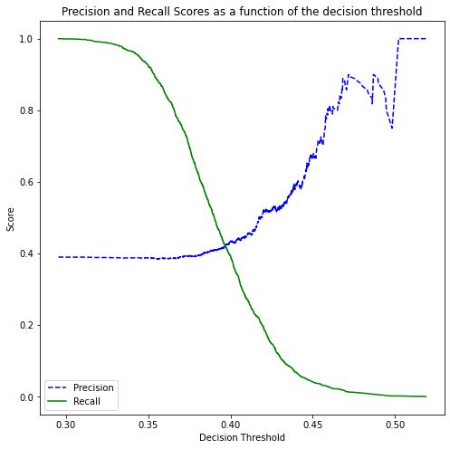

```python
from sklearn.metrics import precision_recall_curve
y=train.Potability
ypred = logit_model.predict(train)
p, r, thresholds = precision_recall_curve(y, ypred)
def plot_precision_recall_vs_threshold(precisions, recalls, thresholds):
    plt.figure(figsize=(8, 8))
    plt.title("Precision and Recall Scores as a function of the decision threshold")
    plt.plot(thresholds, precisions[:-1], "b--", label="Precision")
    plt.plot(thresholds, recalls[:-1], "g-", label="Recall")
    plt.ylabel("Score")
    plt.xlabel("Decision Threshold")
    plt.legend(loc='best')
    plt.legend()
plot_precision_recall_vs_threshold(p, r, thresholds)
```

```python
#Function to compute confusion matrix and prediction accuracy on test/train data
def confusion_matrix_data(data,actual_values,model,cutoff=0.5):
#Predict the values using the Logit model
    pred_values = model.predict(data)
# Specify the bins
    bins=np.array([0,cutoff,1])
#Confusion matrix
    cm = np.histogram2d(actual_values, pred_values, bins=bins)[0]
    cm_df = pd.DataFrame(cm)
    cm_df.columns = ['Predicted 0','Predicted 1']
    cm_df = cm_df.rename(index={0: 'Actual 0',1:'Actual 1'})
# Calculate the accuracy
    accuracy = (cm[0,0]+cm[1,1])/cm.sum()
    fnr = (cm[1,0])/(cm[1,0]+cm[1,1])
    precision = (cm[1,1])/(cm[0,1]+cm[1,1])
    fpr = (cm[0,1])/(cm[0,0]+cm[0,1])
    tpr = (cm[1,1])/(cm[1,0]+cm[1,1])
    fpr_roc, tpr_roc, auc_thresholds = roc_curve(actual_values, pred_values)
    auc_value = (auc(fpr_roc, tpr_roc))# AUC of ROC
    sns.heatmap(cm_df, annot=True, cmap='Blues', fmt='g')
    plt.ylabel("Actual Values")
    plt.xlabel("Predicted Values")
    print("Classification accuracy = {:.1%}".format(accuracy))
    print("Precision = {:.1%}".format(precision))
    print("TPR or Recall = {:.1%}".format(tpr))
    print("FNR = {:.1%}".format(fnr))
    print("FPR = {:.1%}".format(fpr))
    print("ROC-AUC = {:.1%}".format(auc_value))
```

```
Classification accuracy = 56.3%
Precision = 43.4%
TPR or Recall = 39.3%
FNR = 60.7%
FPR = 32.7%
ROC-AUC = 52.8%
```

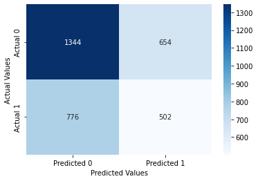

```python
confusion_matrix_data(train,train.Potability,logit_model,0.4)
```

# 6) Data

## 6a) Source

What data sources will you use, and how will the data help solve the problem? Explain. If the data is open source, share the link of the data.

*(0.5 point)*

We will use Kaggle, with a data source that has many measurements of water quality metrics such as pH, TDS, etc. These will help solve the problem because when analyzed together, these metrics can predict the potability of water. Additionally, these metrics are straightforward and can fairly easily be measured with the correct tools, whereas potability is less straightforward and cannot directly be measured. A model that takes in straightforward measurements to predict potability gives policymakers and citizens an idea of how to handle water consumption and treatment.

https://www.kaggle.com/code/gcmadhan/water-quality-prediction-76-h2o-80-accuracy

## 6b) Response & predictors

What is the response, and mention some of the predictors.

*(0.5 point)*

Response is water potability, and predictors are pH value, TDS, Chloramines, hardness, sulfate, conductivity, organic carbon, turbidity, and trihalomethanes.

## 6c) Size

What is the number of continuous predictors, categorical predictors, and observations in your dataset(s). If you are using multiple datasets, please provide the information for each dataset. When counting predictors, count only those that have sufficient non-missing values, and will be useful.

*(1 point)*

9 continuous, 0 categorical. 3276 observations.

# 7) Exisiting solutions

Are there existing solutions of your problem? Almost all Kaggle datasets have exisiting solutions. If yes, then how do you plan to build up on those solutions? **What is the highest model accuracy / performance achieved in the existing solutions?**

*(1 point)*

There are many different solutions for this data set of kaggle. The highest model accuracy we can find (about 89%) comes from someone attempting param tuning on 7 different models. As a self described beginner friendly model, we are confident we will be able to achieve greater accuracy through tuning additional parameters such as decision threshold probability and the regularization parameter. Additionally, we will stratify and scale the datasets (which other solutions do not appear to do). Laslty, if needed, we will include polynomial splines to best set out model.

# 8) Stakeholders

Who are the stakeholders, and how will your project benefit them? Explain.

*(1 point)*

The stakeholders are mainly policymakers, but also citizens. The project will be able to predict water potability and health based on easily measurable data points in order to support the development of sanitation and help determine how much a city should invest in water sanitation. Additionally, by prediciting water quality based on these simple metrics, it helps citizens understand how much additional care they may need to take in terms of water quality and their own drinking water.

# 9) Work-split

*(This question is answered for you)*

How do you plan to split the project work amongst individual team members?

We will learn to develop and tune the following models in the STAT303 sequence:

1. MARS
2. Decision trees with cost-complexity pruning
3. Bagging (Bagging MARS / decision trees)
4. Random Forests
5. AdaBoost
6. Gradient boosting
7. XGBoost
8. Lasso / Ridge / Stepwise selection

Each team member is required to develop and tune at least one of the above models. In the end, the team will combine all the developed models to create a model more accurate than each of the individual models.

*(0 points)*